# Project: Explore and Summarize Data

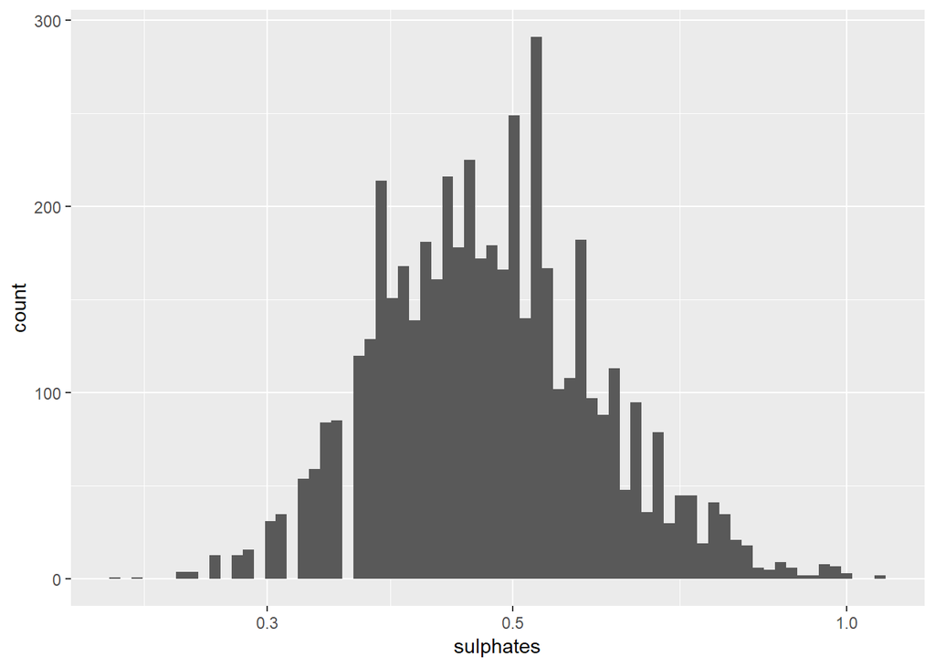

Plotting on a log scale shows that data distributed normaly with some breaks.

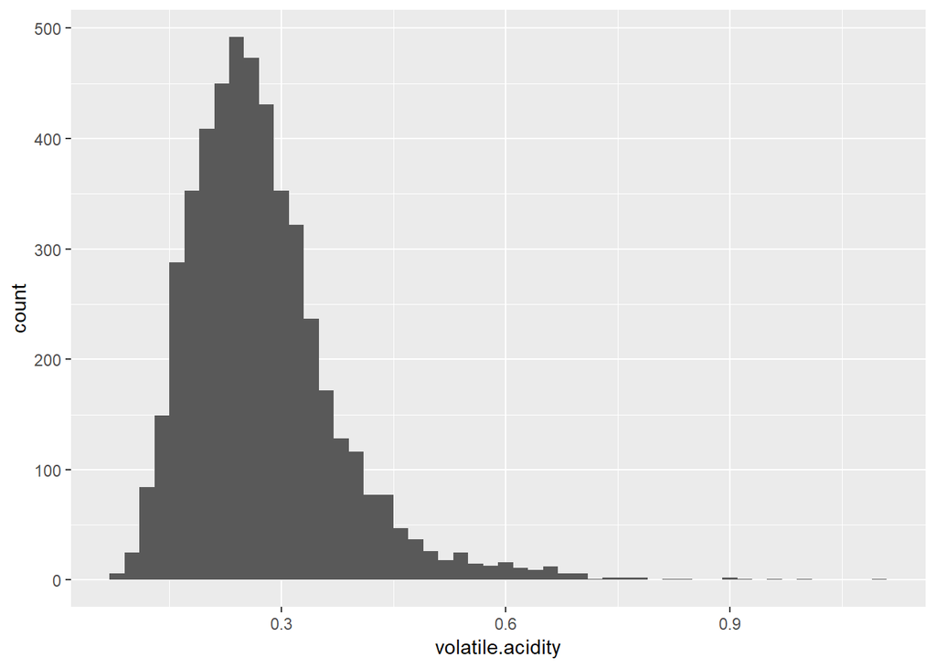

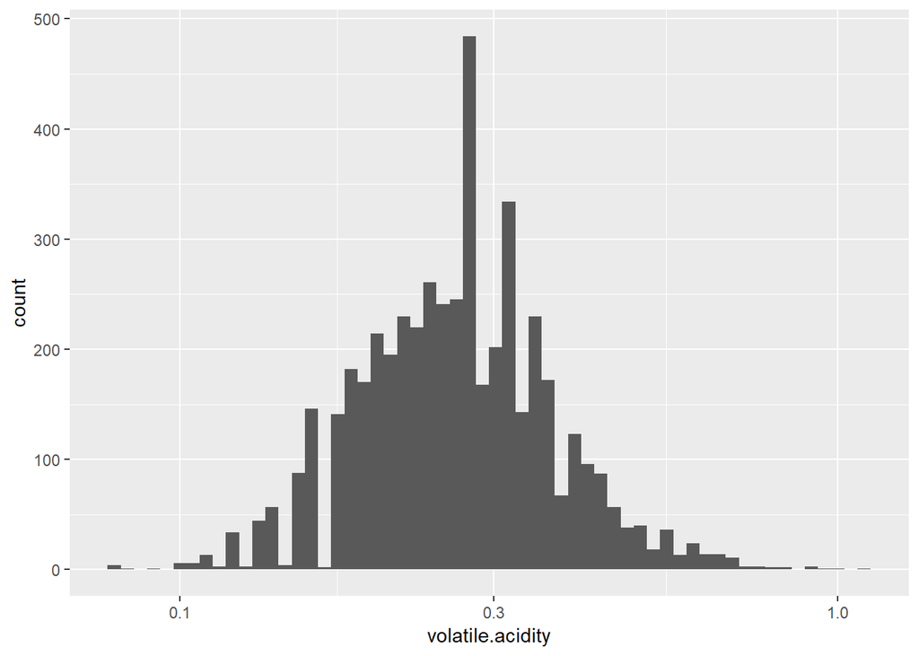

```
##    Min. 1st Qu.  Median    Mean 3rd Qu.    Max.
##  0.0800  0.2100  0.2600  0.2782  0.3200  1.1000
```

Volatile acidity, which at too high of levels can lead to an unpleasant, vinegar taste, peaks at just below 0.3 level. Now lets observe how volatile acidity level looks like for wines with higher quality.

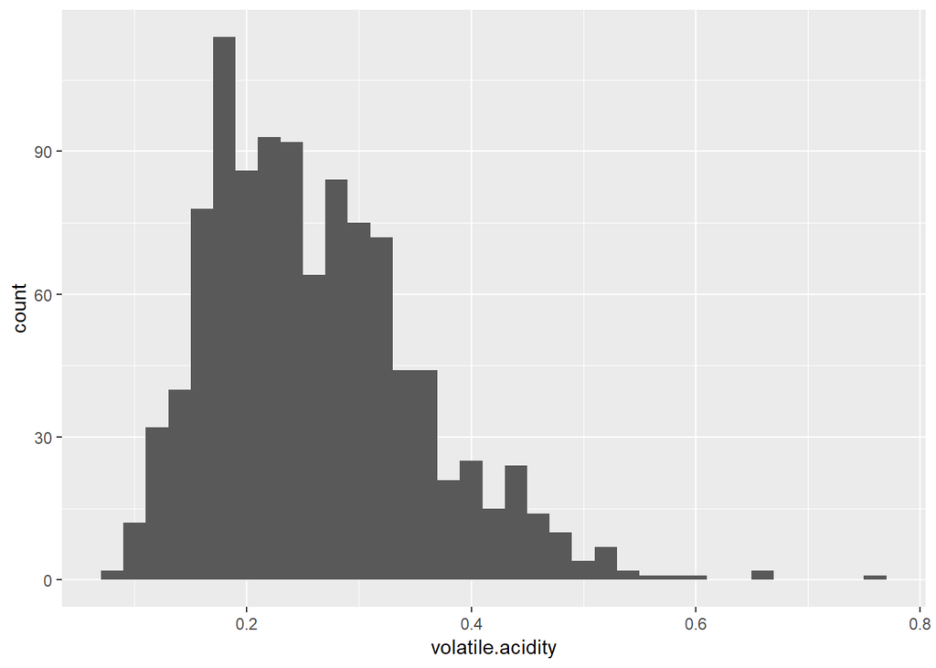

```
## <ScaleContinuousPosition>
##  Range:
##  Limits:    0 --    1
```

```
##    Min. 1st Qu.  Median    Mean 3rd Qu.    Max.
##  0.0800  0.1900  0.2500  0.2653  0.3200  0.7600
```

For higher quality wines(rated 7, 8, 9) the volatile mean and meadian level is little bit lower.

# Univariate Analysis

There are 4898 white wines with 13 feature(Fixed acidity, volatile acidity, citric acid, residual sugar, chlorides, free sulfur dioxode, total sulfur dioxide, density, pH, sulphates, alcohol, and quality). All of them are numeric values and quality measured only in a whole number.

Other observations: * Most of the wines have a quality of 5, 6, or 7. * Other attributes explored so far have quite normal distribution.

The main feature of this data set is quality. I’d like to determine which attributes have the biggest effect on the quality.

I think volatile acidity, citric acid, chlorides, total sulfur dioxide likely to contribute to the quality of wine because they directly effect the taste or smell of the wine.

I have not created new variables so far.

I log transformed some of the data to have a better understanding of the distribution. What I have notcied it is that most of wines have low residual sugar level which determines the sweetness of the wine.

# Bivariate Plots Section

There are 4898 different white wines with 13 variables including:

```
##                                 X fixed.acidity volatile.acidity
## X                     1.000000000   -0.25581431      0.002857966
## fixed.acidity        -0.255814305    1.00000000     -0.022697290
## volatile.acidity      0.002857966   -0.02269729      1.000000000
## citric.acid          -0.149899918    0.28918070     -0.149471811
## residual.sugar        0.006623775    0.08902070      0.064286060
## chlorides            -0.045645192    0.02308564      0.070511571
## free.sulfur.dioxide  -0.011928911   -0.04939586     -0.097011939
## total.sulfur.dioxide -0.161979037    0.09106976      0.089260504
## density              -0.185976097    0.26533101      0.027113845
## pH                   -0.115774132   -0.42585829     -0.031915368
## sulphates             0.009807759   -0.01714299     -0.035728147
## alcohol               0.213656245   -0.12088112      0.067717943
## quality               0.035763247   -0.11366283     -0.194722969
##                       citric.acid residual.sugar   chlorides
## X                    -0.149899918    0.006623775 -0.04564519
## fixed.acidity         0.289180698    0.089020701  0.02308564
## volatile.acidity     -0.149471811    0.064286060  0.07051157
## citric.acid           1.000000000    0.094211624  0.11436445
## residual.sugar        0.094211624    1.000000000  0.08868454
## chlorides             0.114364448    0.088684536  1.00000000
## free.sulfur.dioxide   0.094077221    0.299098354  0.10139235
## total.sulfur.dioxide  0.121130798    0.401439311  0.19891030
## density               0.149502571    0.838966455  0.25721132
## pH                   -0.163748211   -0.194133454 -0.09043946
## sulphates             0.062330940   -0.026664366  0.01676288
## alcohol              -0.075728730   -0.450631222 -0.36018871
## quality              -0.009209091   -0.097576829 -0.20993441
##                      free.sulfur.dioxide total.sulfur.dioxide     density
## X                          -0.0119289106         -0.161979037 -0.18597610
## fixed.acidity              -0.0493958591          0.091069756  0.26533101
## volatile.acidity           -0.0970119393          0.089260504  0.02711385
## citric.acid                 0.0940772210          0.121130798  0.14950257
## residual.sugar              0.2990983537          0.401439311  0.83896645
## chlorides                   0.1013923521          0.198910300  0.25721132
## free.sulfur.dioxide         1.0000000000          0.615500965  0.29421041
## total.sulfur.dioxide        0.6155009650          1.000000000  0.52988132
## density                     0.2942104109          0.529881324  1.00000000
## pH                         -0.0006177961          0.002320972 -0.09359149
## sulphates                   0.0592172458          0.134562367  0.07449315
## alcohol                    -0.2501039415         -0.448892102 -0.78013762
## quality                     0.0081580671         -0.174737218 -0.30712331
##                                 pH    sulphates     alcohol      quality
## X                    -0.1157741316  0.009807759  0.21365624  0.035763247
## fixed.acidity        -0.4258582910 -0.017142985 -0.12088112 -0.113662831
## volatile.acidity     -0.0319153683 -0.035728147  0.06771794 -0.194722969
## citric.acid          -0.1637482114  0.062330940 -0.07572873 -0.009209091
## residual.sugar       -0.1941334540 -0.026664366 -0.45063122 -0.097576829
## chlorides            -0.0904394560  0.016762884 -0.36018871 -0.209934411
## free.sulfur.dioxide  -0.0006177961  0.059217246 -0.25010394  0.008158067
## total.sulfur.dioxide  0.0023209718  0.134562367 -0.44889210 -0.174737218
## density              -0.0935914935  0.074493149 -0.78013762 -0.307123313
## pH                    1.0000000000  0.155951497  0.12143210  0.099427246
## sulphates             0.1559514973  1.000000000 -0.01743277  0.053677877
## alcohol               0.1214320987 -0.017432772  1.00000000  0.435574715
## quality               0.0994272457  0.053677877  0.43557472  1.000000000
```

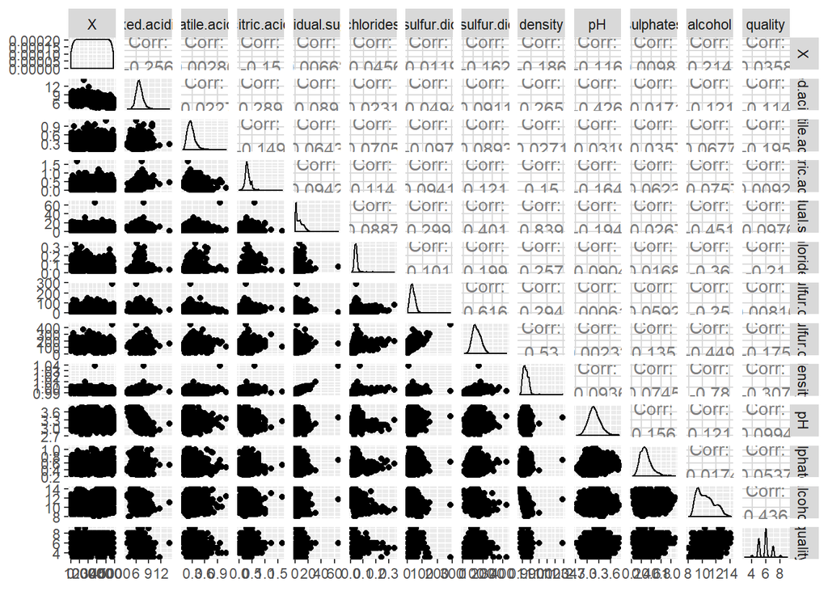

Density correlates with alcohol and sugar content which makes sense as the density of water is close to that of water depending on the percent of alcohol and sugar content.

Free sulfur dioxide correlates with total sulfur dioxide which also make sense as free sulfur dioxide is a fraction of total amount.

The strongest correlation quality has with density, alcohol, chlorides, and volatile acidity which makes sense because they directly affect the taste of the wine. Let’s take a closer look at scatter plots involving quality and listed above attributes.

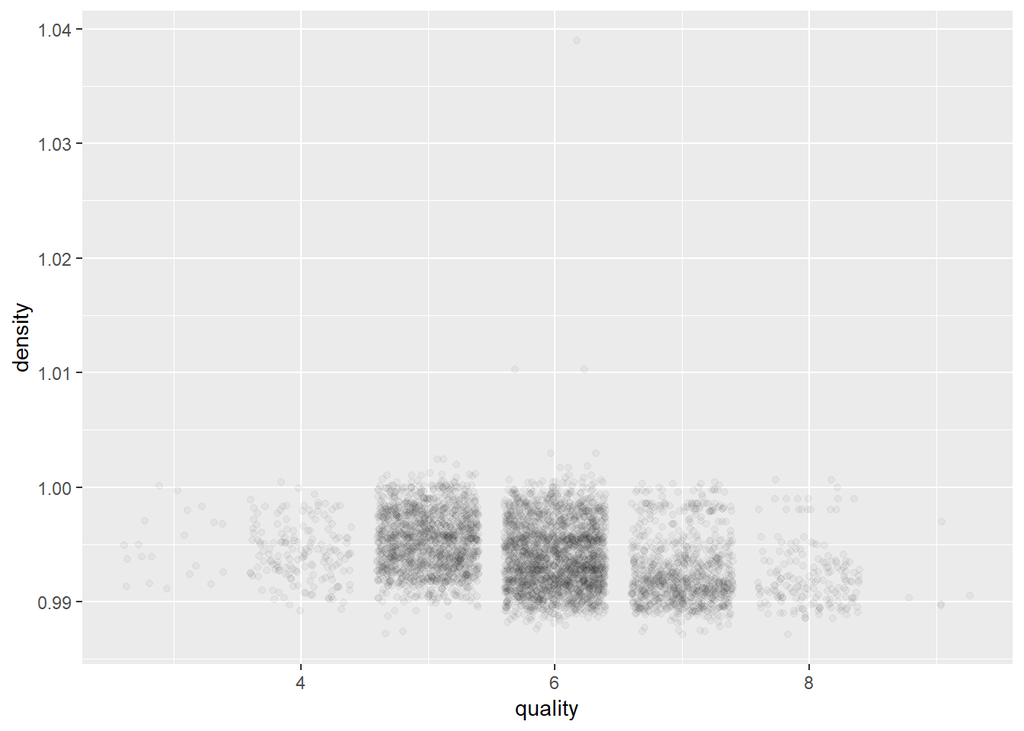

After deaper exploration it looks like correlation between quality and density isn’t very strong.

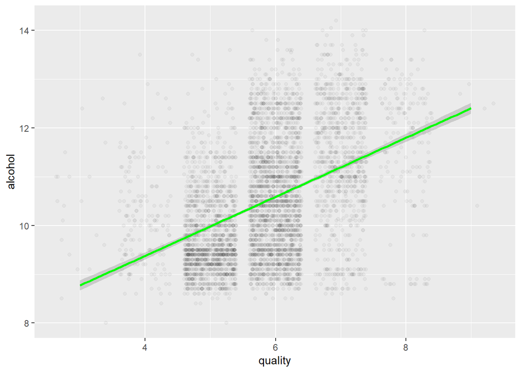

With correlation line, it looks like higher quality wines tend to higher alcohol level.

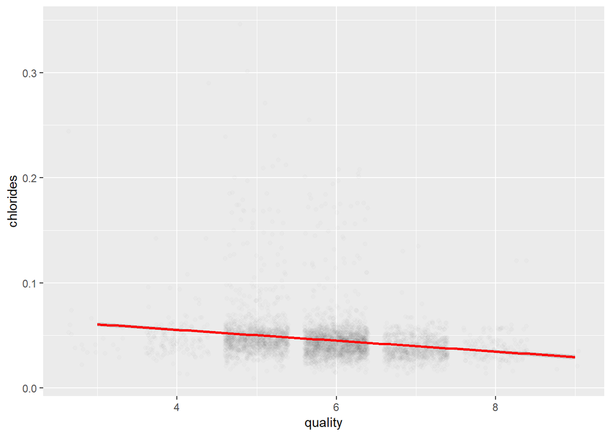

Although the correlation isn’t very strong it is negative which makes sense since chlorides is the amount of salt in the wine which might affect the taste.

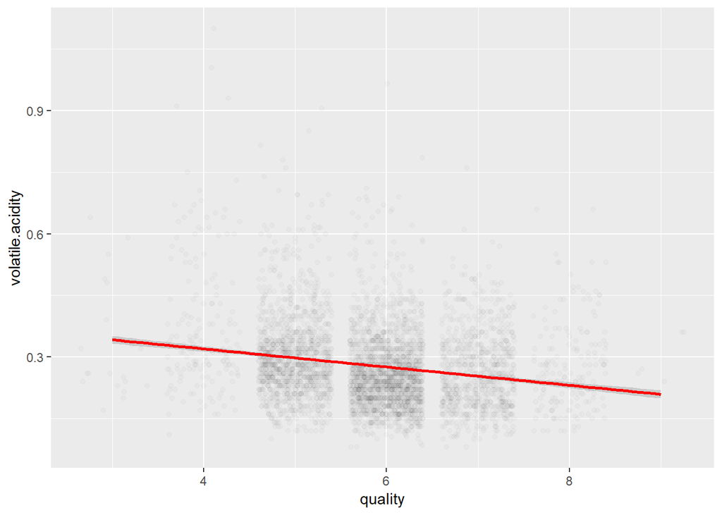

Volatile acidity is a very similar case to chlorides above as too high levels can lead to an unpleasant, vinegar taste.

Now, I want to take a closer look at the alcohol level for different quality levels.

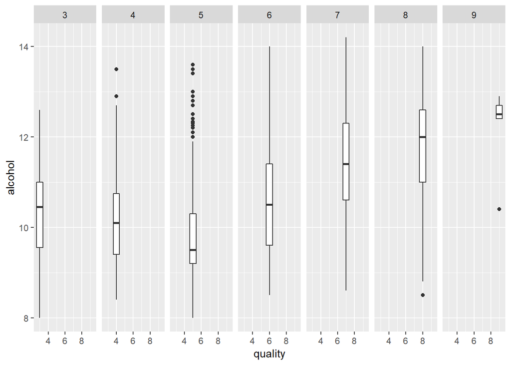

It looks interesting since it is not a linear correlation because wines with quality 5 have the lowest level of alcohol.

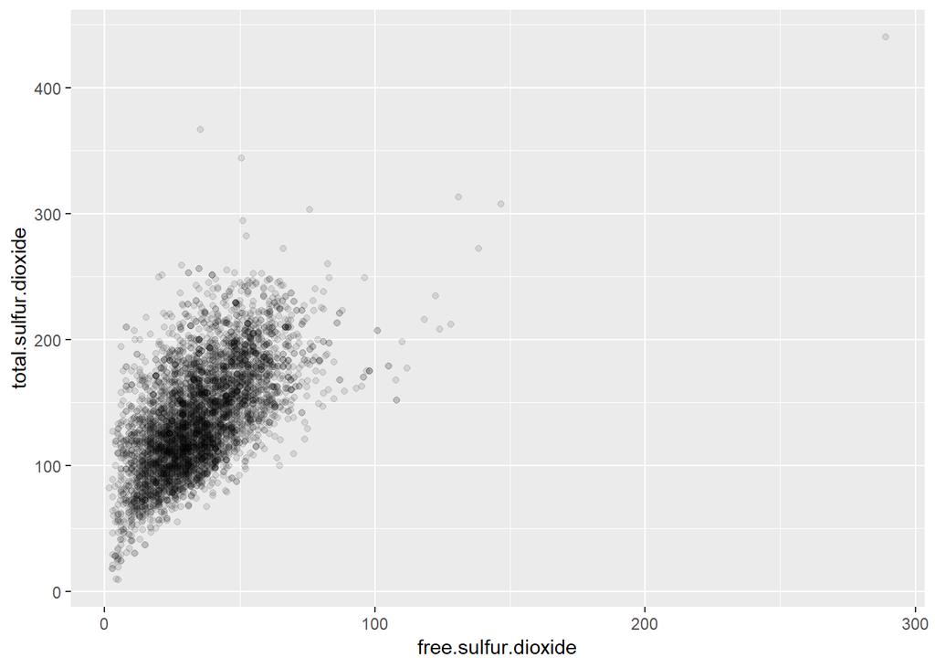

It is an obvious correlation between them which is expected.

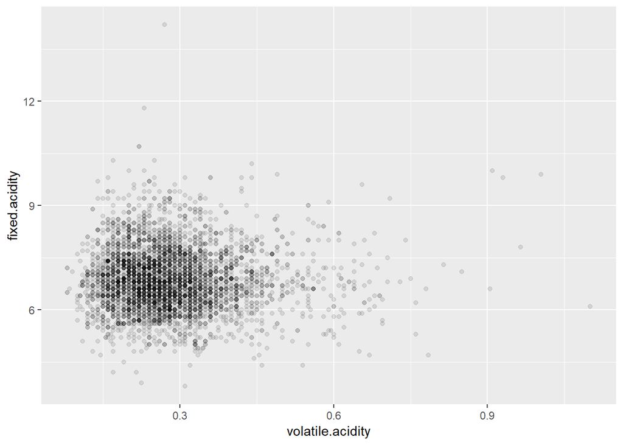

Fixed acidity and volatile acidity are both very centralized at lower levels.

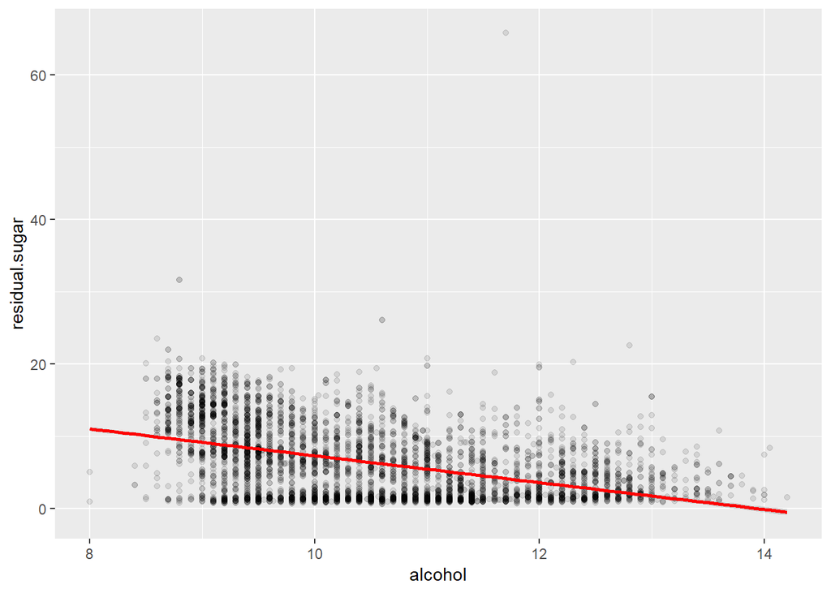

Wines with higher alcohol tend to have less sugar amount.

# Bivariate Analysis

After plotting some box plots and scatter plots I found out how attributes correlate with quality. Majority of them affect how it was assumes based on the correlation data I got at the beginning, however, I found interesting trend about alcohol level which I would like to explore more as it is one of the strongest relations.

Then I looked into some relation between the attributes of the quality of the wine. Majority of them performed as expected. Interesting that wines with higher alcohol level have less sugar.

# Multivariate Plots Section

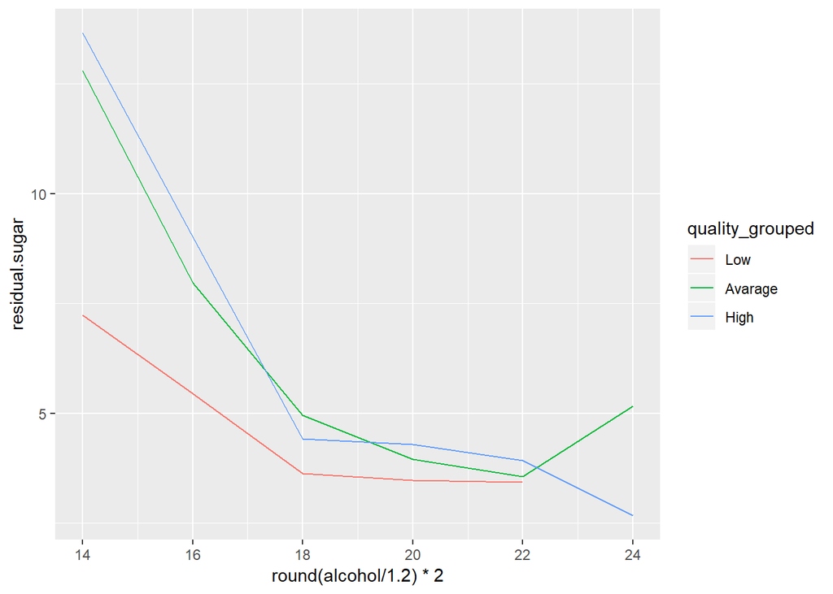

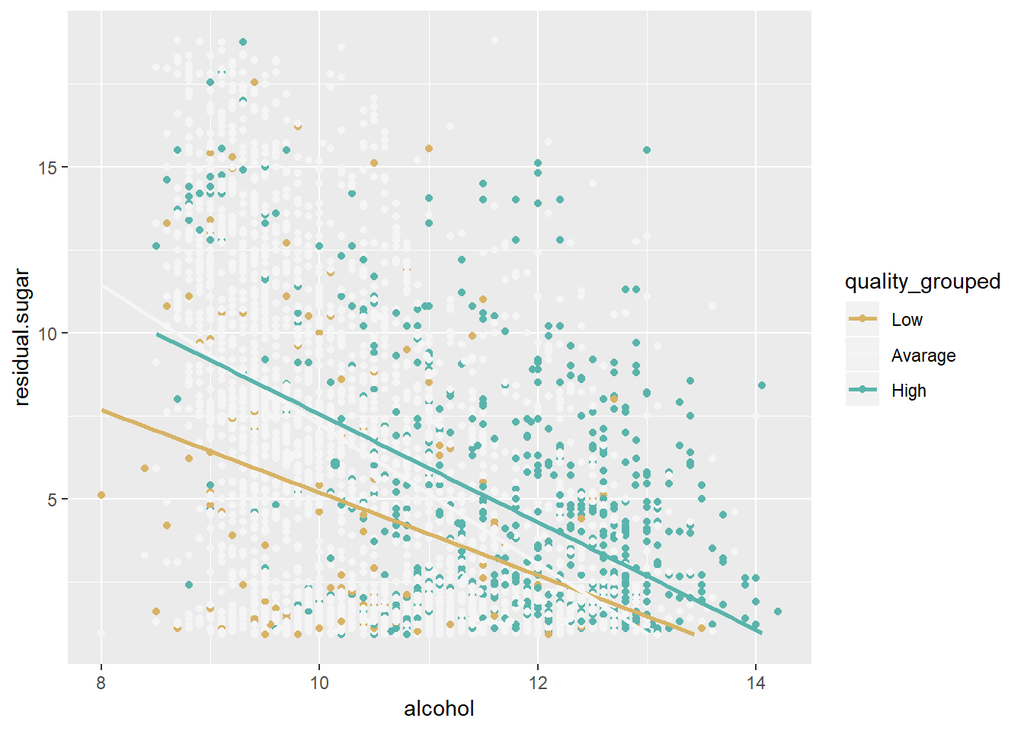

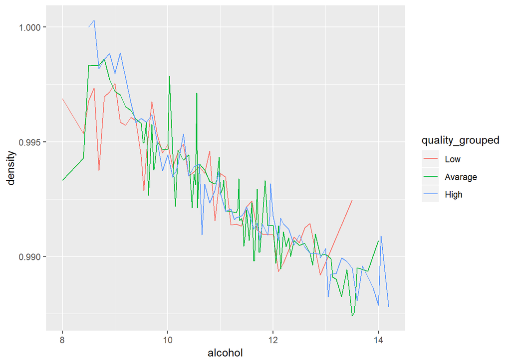

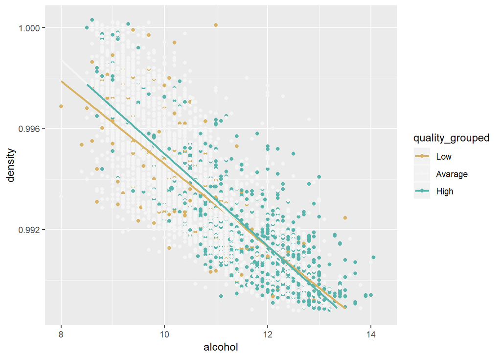

There is a negative correlation between density and alcohol for wines of different quality.

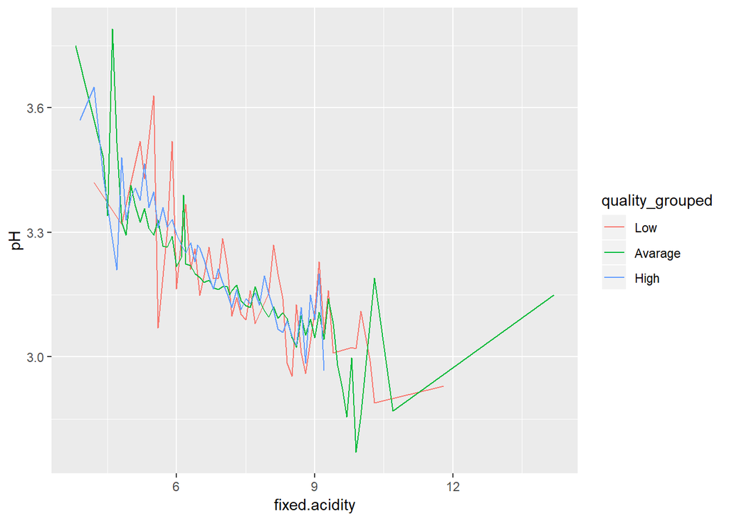

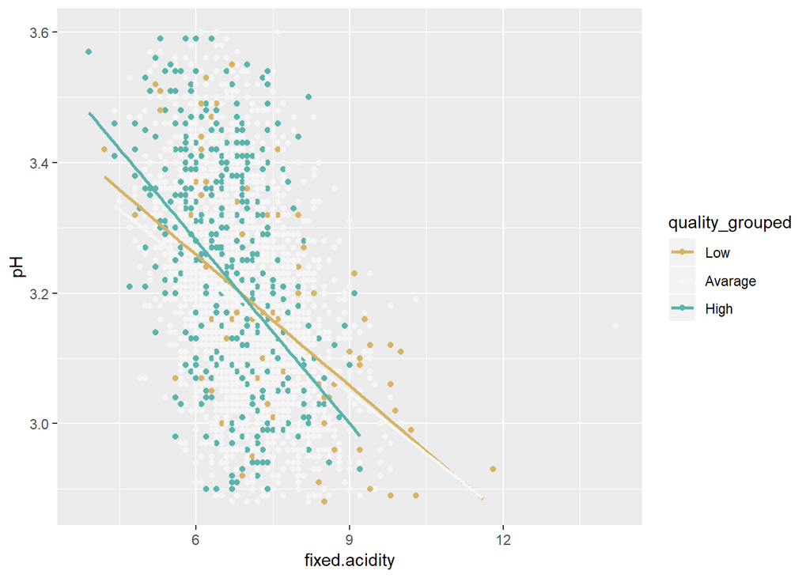

Correlation between pH and fixed acidity is also confirmed for all wine qualities.

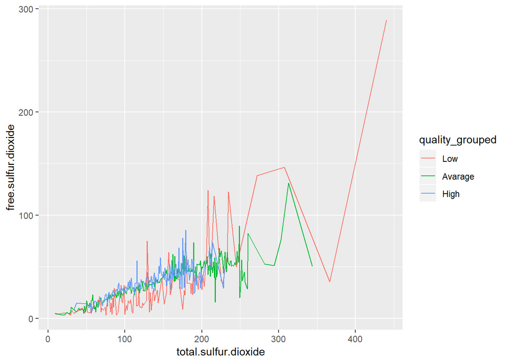

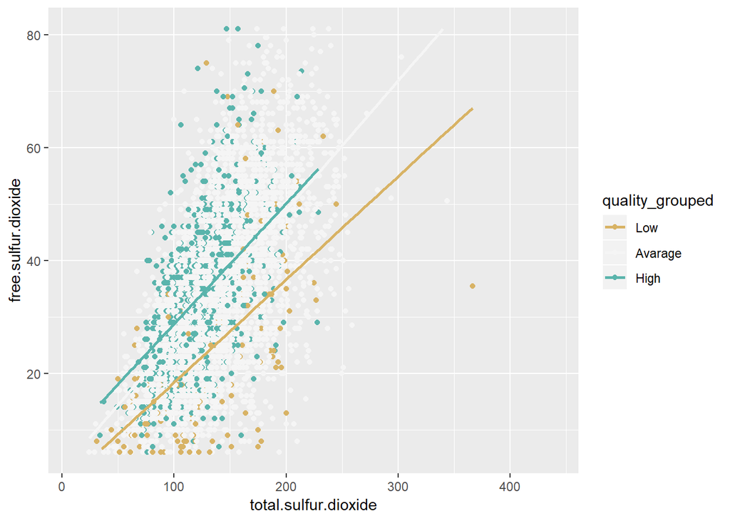

Once again it seems like there is the same trend for all quality of wines.

# Multivariate Analysis

Multivariate Analysis supports and confirms many findings from Bivariate Analysis section. Additionally, it allowed seeing the differences between the different qualities of wines. Although it looks like the different quality of wines follows the same trend sometime it might slightly vary.

Some interesting findings include higher alcohol level with lower density level and lower residual sugar level for higher alcohol levels which is interesting.

# Final Plots and Summary

### Plot One

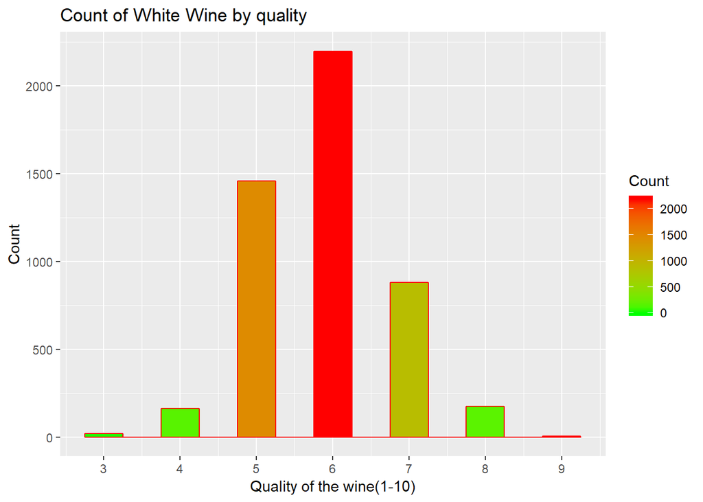

### Description One

This is a basic graph which helps to understand us the distribution of wines by quality. There are not that many wines at higher or lower levels. Most of them are in the middle which is an important factor to account when doing the analysis.

### Plot Two

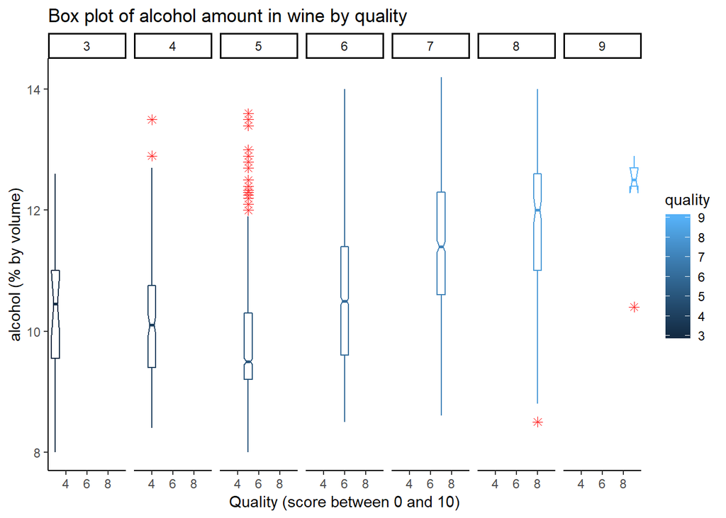

### Description Two

I find this box plot very interesting because it shows that low-quality wines have higher alcohol level than average ones. This proves that quality and alcohol is not a linear correlation.

### Plot Three

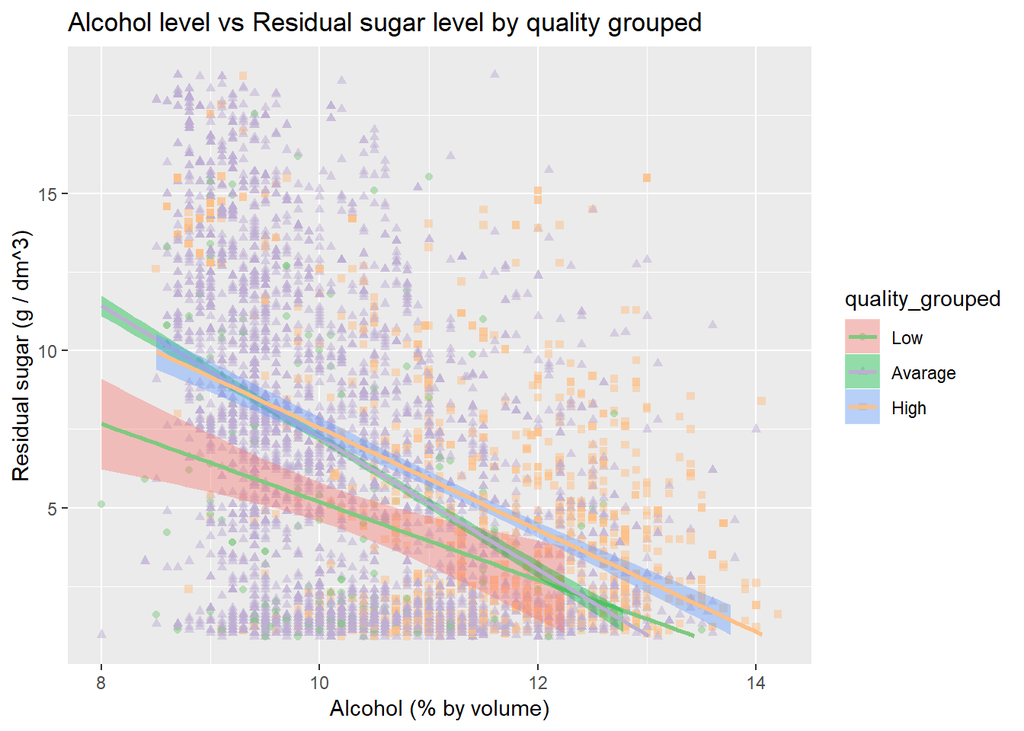

### Description Three

# Reflection

The main purpose and goal of my analysis was to find any significant differences between high and low-quality wine. This data set of different white wines was limited as the majority of wines fall into average quality. It was difficult for me to track a small change which would affect the quality of the wine. Although I was able to find some attributes such as residual sugar, density, chlorides which do affect the quality the effect seems to be very similar.

I think this data would be more interesting to explore if it would include a description oh how actually score was generated as well as to include the price of each wine.

# Reference

https://briatte.github.io/ggcorr/

https://www.rstudio.com/wp-content/uploads/2015/03/ggplot2-cheatsheet.pdf

Udacity Resoureces

Data: P. Cortez, A. Cerdeira, F. Almeida, T. Matos and J. Reis. Modeling wine preferences by data mining from physicochemical properties. In Decision Support Systems, Elsevier, 47(4):547-553. ISSN: 0167-9236.